# A Thiopurine-like Mutagenic Process Defines TGCT Subtypes

Tongwu Zhang

2025-11-17

## 1 Overview

This R Markdown document reproduces the main analyses and figures for TCGA-TGCT WGS dataset

Manuscript title: A Thiopurine-like Mutagenic Process Defines TGCT Subtype

## 2 Fig. 5: Early and Widespread Whole-Genome Doubling (WGD) and Clonal Architecture in TGCTs.

## 3 Load Required Libraries and Set Plotting Styles

(You may need to install some packages if missing)

```r
source('../functions/Sherlock_functions.R')

set_wd()
```

```
## [1] "/Users/zhangt8/NIH-Work/Earl_Stadtman_Inverstigator/Projects/TCGA_TGCT/biowulf/Rmarkdown/Rscripts"
## [1] "ok"
```

```r
libztw()
pdfhr()
pdfhr2()

# Load R object WGS analysis results --------------------------------------

load('../data/wgs_data.RData')
load('../data/wgs_clinical.RData')
load('../data/ngspurity_data.RData')
```

## 4 Fig. 5a

Distribution of tumors with minimal cancer cell fraction (CCF) of subclones in seminomas and non-seminomas, with non-seminomas showing higher intratumoral heterogeneity.

```r
# Number of Subclones -----------------------------------------------------
load('../data/DP_info_data.RData', verbose = T)
```

```
## Loading objects:
##   DP_info_data
##   Cluster_info
```

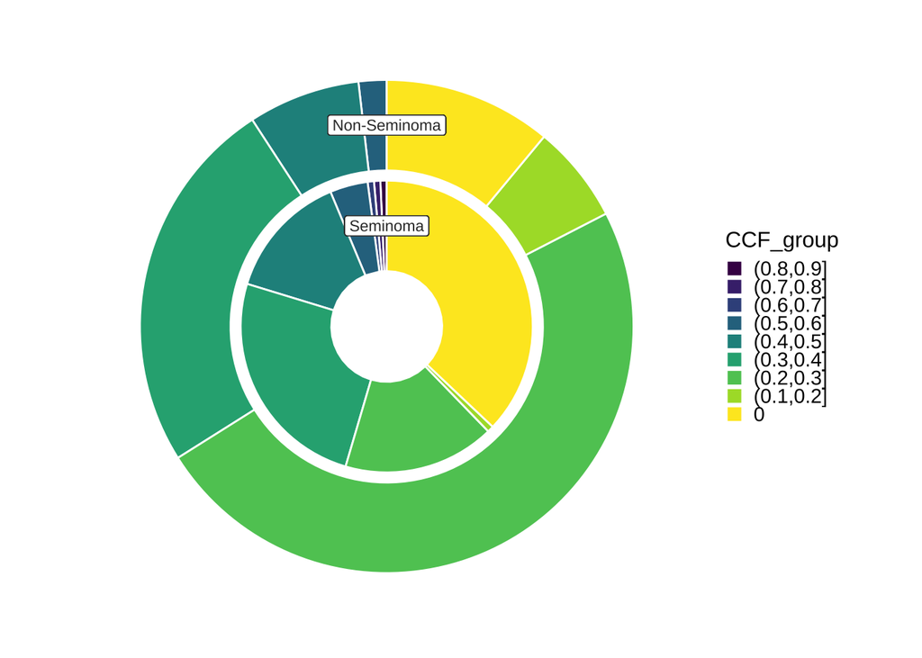

```r
load('../data/ngspurity_data.RData')

library(plotthis)

pdata <- Cluster_info %>%
  filter(Clone == "N") %>%
  group_by(Tumor_Barcode) %>%
  summarise(N = n(), CCF = min(Cluster_CCF)) %>%
  right_join(wgs_data %>% select(Tumor_Barcode, Subtype)) %>%
  mutate(CCF = if_else(is.na(N), 0, CCF)) %>%
  mutate(N = if_else(is.na(N), 0, N)) %>%
  arrange(CCF) %>%
  group_by(Subtype) %>%
  mutate(seq = seq_along(CCF)) %>%
  ungroup()

pdata <- pdata %>%
  mutate(
    CCF_group = case_when(
      CCF == 0 ~ "0",
      CCF > 0 & CCF <= 0.05 ~ "(0,0.05]",
      CCF > 0.05 & CCF <= 0.1 ~ "(0.05,0.1]",
      CCF > 0.1 & CCF <= 0.2 ~ "(0.1,0.2]",
      CCF > 0.2 & CCF <= 0.3 ~ "(0.2,0.3]",
      CCF > 0.3 & CCF <= 0.4 ~ "(0.3,0.4]",
      CCF > 0.4 & CCF <= 0.5 ~ "(0.4,0.5]",
      CCF > 0.5 & CCF <= 0.6 ~ "(0.5,0.6]",
      CCF > 0.6 & CCF <= 0.7 ~ "(0.6,0.7]",
      CCF > 0.7 & CCF <= 0.8 ~ "(0.7,0.8]",
      CCF > 0.8 ~ "(0.8,0.9]",
      TRUE ~ "Other" # Catch-all for any unexpected values
    ),
    # Optional: Make it a factor with ordered levels
    CCF_group = factor(
      CCF_group,
      levels = c(
        "0",
        "(0,0.05]",
        "(0.05,0.1]",
        "(0.1,0.2]",
        "(0.2,0.3]",
        "(0.3,0.4]",
        "(0.4,0.5]",
        "(0.5,0.6]",
        "(0.6,0.7]",
        "(0.7,0.8]",
        "(0.8,0.9]",
        "Other"
      )
    )
  )

pdata %>%
  count(CCF_group, Subtype) %>%
  mutate(Subtype = fct_rev(Subtype)) %>%
  RingPlot(
    x = 'Subtype',
    y = 'n',
    group_by = 'CCF_group',
    group_by_sep = "A",
    group_name = 'Minimal CCF of detected subclones'
  ) +
  scale_fill_viridis_d()
```

## Fig. 5b Comparison of clonal versus subclonal mutation proportions between seminomas and non-seminomas.

```r
load('../data/clsdata.RData',verbose = T)
```

```
## Loading objects:
##   clsdata
##   clscolors
```

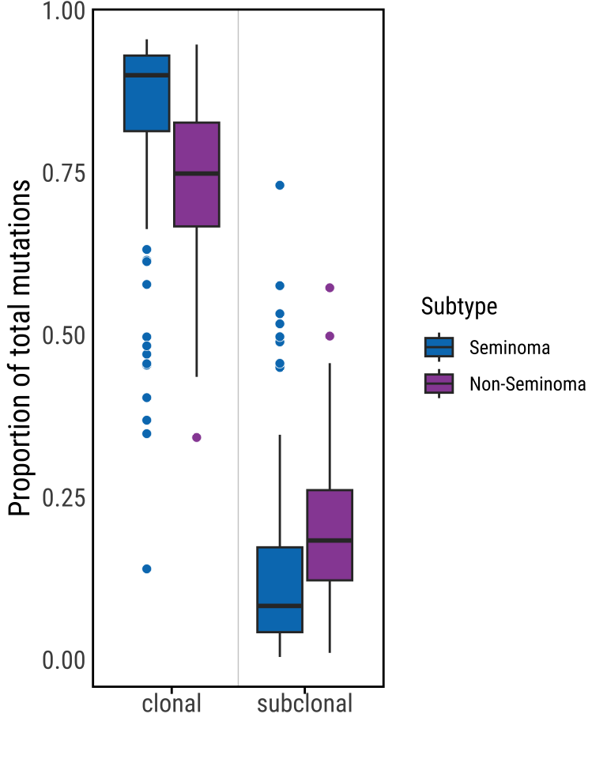

```r
clsdata2 <- clsdata %>%
  mutate(CLS = if_else(str_starts(CLS, 'clonal'), 'clonal', CLS)) %>%
  group_by(Tumor_Barcode, CLS) %>%
  summarise(n = sum(n), Freq = sum(Freq)) %>%
  ungroup()


clsdata2 %>%
  left_join(wgs_data) %>%
  filter(!is.na(CLS)) %>%
  ggplot(aes(CLS, Freq, fill = Subtype)) +
  geom_boxplot(
    outlier.shape = 21,
    outlier.color = 'white',
    outlier.size = 2,
    outlier.stroke = 0.2
  ) +
  geom_vline(xintercept = c(1.5), linewidth = 0.25, col = '#cccccc') +
  labs(x = "", y = "Proportion of total mutations", fill = 'Subtype') +
  scale_fill_manual(values = subtypecol, breaks = names(subtypecol)) +
  theme_ipsum_rc(
    axis_text_size = 12,
    axis_title_just = 'm',
    axis_title_size = 14,
    grid = F
  ) +
  theme(
    axis.ticks.x = element_line(linewidth = .5),
    plot.margin = margin(4, 4, 4, 4)
  ) +
  #theme(legend.position = 'top',legend.direction = 'horizontal')+
  panel_border(color = 'black')
```

## 5 Fig. 5c

Ternary plot illustrating genome-wide major copy number (MCN) composition to infer WGD status. Each point represents a tumor, colored by subtype and shaped by WGD category. Tumors are classified as non-WGD, single WGD, or multiple WGD based on the relative proportions of the autosomal genome with MCN = 1, 2, or ≥3.

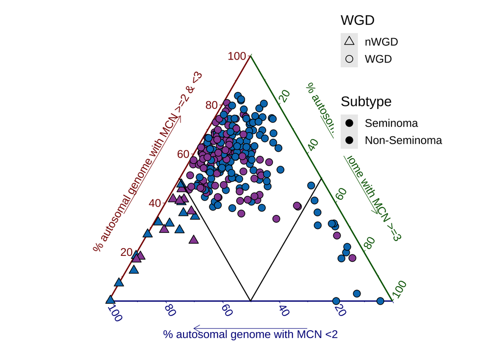

```r
load('../data/MCN_data.RData')
#library(ggtern)
MCN_data %>%
  mutate(MCN_R1 = 1 - MCN_R2 - MCN_R3) %>%
  ggtern::ggtern(ggtern::aes(MCN_R1, MCN_R2, MCN_R3, fill = Subtype, shape = WGD)) +
  ggtern::geom_mask() +
  geom_point(size = 3) +
  scale_shape_manual(values = c(24, 21)) +
  scale_fill_manual(values = ncicolpal[c(4, 5)]) +
  ggtern::theme_rgbw(base_size = 14, base_family = 'Roboto') +
  ggtern::theme_nogrid() +
  ggtern::theme_hidetitles() +
  ggtern::theme_clockwise() +
  ggtern::theme_legend_position('tr') +
  ggtern::geom_Lline(Lintercept = 0.5) +
  ggtern::geom_Rline(Rintercept = 0.5) +
  labs(
    xarrow = '% autosomal genome with MCN <2',
    yarrow = '% autosomal genome with MCN >=2 & <3',
    zarrow = '% autosomal genome with MCN >=3'
  )
```

## 6 Fig. 5d

```r
sample_wgd2 <- MCN_data %>% filter(MCN_R3 > 0.5) %>% pull(Tumor_Barcode)
load('../data/tgct_signature_probability.RData', verbose = T)
```

```
## Loading objects:
##   tgct_sbs96_probability
```

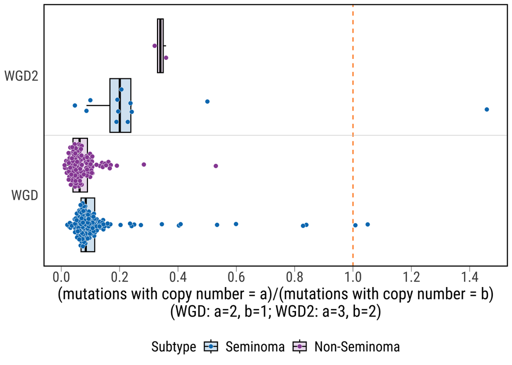

```r
DP_info_data <- DP_info_data %>% left_join(tgct_sbs96_probability)

tmp <- DP_info_data %>%
  filter(no.chrs.bearing.mut %in% c(1, 2, 3)) %>%
  rename(CNV_WGD = no.chrs.bearing.mut) %>%
  group_by(Tumor_Barcode, CNV_WGD) %>%
  summarise(CNV = sum(SBS1 + SBS5, na.rm = T))

tmp <- DP_info_data %>%
  count(Tumor_Barcode, name = 'Total') %>%
  left_join(tmp)
tmp <- tmp %>% replace_na(list(CNV = 0))

tmp <- ngspurity %>%
  select(Tumor_Barcode, WGD_Status = MCN_WGD) %>%
  left_join(tmp) %>%
  left_join(wgs_data %>% select(Tumor_Barcode, Subtype)) %>%
  mutate(Ratio = CNV / Total)


# tidyHeatmap::heatmap(
#   tmp,.row = Tumor_Barcode,.column = CNV_WGD,.value = Ratio
# )

tmp1 <- left_join(
  tmp %>%
    filter(CNV_WGD == 1) %>%
    select(Tumor_Barcode, Subtype, Total, Ratio1 = Ratio),
  tmp %>%
    filter(WGD_Status == 'WGD', CNV_WGD == 2) %>%
    select(Tumor_Barcode, Ratio2 = Ratio) %>%
    mutate(Group = 'WGD')
) %>%
  filter(!is.na(Group)) %>%
  mutate(R = Ratio2 / Ratio1, Subratio = Ratio1 + Ratio2) %>%
  select(Group, Subtype, Tumor_Barcode, Subratio, Total, R)

tmp2 <- left_join(
  tmp %>%
    filter(CNV_WGD == 2) %>%
    select(Tumor_Barcode, Subtype, Total, Ratio1 = Ratio),
  tmp %>%
    filter(
      WGD_Status == 'WGD',
      CNV_WGD == 3,
      Tumor_Barcode %in% sample_wgd2
    ) %>%
    select(Tumor_Barcode, Ratio2 = Ratio) %>%
    mutate(Group = 'WGD2')
) %>%
  filter(!is.na(Group)) %>%
  mutate(R = Ratio2 / Ratio1, Subratio = Ratio1 + Ratio2) %>%
  select(Group, Subtype, Tumor_Barcode, Subratio, Total, R)


pdata <- bind_rows(tmp1, tmp2)

pdata %>%
  ggplot(aes(Group, R, fill = Subtype)) +
  #geom_violin(trim=T,size=0.2)+
  geom_boxplot(width = 1, color = 'black', outlier.shape = NA, alpha = 0.2) +
  ggbeeswarm::geom_quasirandom(
    pch = 21,
    size = 2,
    width = 0.2,
    color = "white",
    stroke = 0.2,
    dodge.width = 1
  ) +
  geom_hline(yintercept = 1, linetype = 2, col = ncicolpal[2]) +
  geom_vline(xintercept = 1.5, col = '#cccccc', size = 0.2) +
  labs(
    x = NULL,
    y = '(mutations with copy number = a)/(mutations with copy number = b)\n(WGD: a=2, b=1; WGD2: a=3, b=2)'
  ) +
  scale_fill_manual(values = subtypecol) +
  scale_y_continuous(breaks = pretty_breaks(n = 7)) +
  theme_ipsum_rc(
    axis_text_size = 14,
    axis_title_just = 'm',
    axis_title_size = 16,
    grid = F,
    ticks = T
  ) +
  panel_border(color = 'black') +
  theme(
    #axis.text.x = element_blank(),
    panel.spacing.x = unit(0.4, 'cm'),
    axis.ticks.y = element_blank(),
    plot.margin = margin(4, 4, 4, 4),
    legend.position = 'bottom',
    legend.text = element_text(size = 14),
    legend.title = element_text(size = 14),
    strip.text.x = element_text(hjust = 0.5, face = 'bold', size = 16)
  ) +
  scale_color_manual(values = c(ncicolpal[1], 'black')) +
  guides(color = 'none') +
  coord_flip()
```

```r
ggsave(
  filename = 'WGD_timing_subtypes_SBS15.pdf',
  width = 8,
  height = 4,
  device = cairo_pdf
)
```

## 7 Fig. 5e

```r
# WGS timming and clonal structure/drivers  -------------------------------
# WGD timming -------------------------------------------------------------
load('../data/wgs_data.RData')
load('../data/ngspurity_data.RData')
load('../data/DP_info_data.RData', verbose = T)
```

```
## Loading objects:
##   DP_info_data
##   Cluster_info
```

```r
load('../data/clsdata.RData')
#load('../ZTW_functions.RData')
tmp <- DP_info_data %>%
  filter(no.chrs.bearing.mut == 2) %>%
  count(Tumor_Barcode, name = "CNV2")

tmp <- DP_info_data %>%
  count(Tumor_Barcode, name = 'Total') %>%
  left_join(tmp)
tmp <- tmp %>% replace_na(list(CNV2 = 0))

tdata <- ngspurity %>%
  select(Tumor_Barcode, WGD_Status = MCN_WGD) %>%
  left_join(tmp) %>%
  mutate(Ratio = CNV2 / Total)


# driver gene
load('../data/tgct_mtvcf.RData', verbose = T)
```

```
## Loading objects:
##   tgct_mtvcf
```

```r
load('../data/tgct_maf.RData', verbose = T)
```

```
## Loading objects:
##   tgct_maf_freq
##   tgct_maf_freq_nonseminoma
##   tgct_maf_freq_seminoma
##   tgct_maf
```

```r
#load('tgct_driver_mutations.RData')
load('../data/intogene_drivers.RData', verbose = T)
```

```
## Loading objects:
##   intogene
```

```r
genelist <- intogene %>% pull(SYMBOL)

tmp <- tgct_mtvcf %>% select(Tumor_Barcode, MutationID, CLS)

#tmp <- tgct_maf %>%
tmp <- tgct_maf %>%
  mutate(Chromosome = str_remove(Chromosome, "^chr")) %>%
  mutate(
    MutationID = paste(
      Chromosome,
      Start_Position,
      Reference_Allele,
      Tumor_Seq_Allele2,
      sep = ':'
    )
  ) %>%
  select(Tumor_Barcode, MutationID, Hugo_Symbol, Variant_Classification) %>%
  left_join(tmp)

tmpdata <- tmp %>%
  left_join(wgs_data %>% select(Tumor_Barcode, Subtype)) %>%
  filter(Hugo_Symbol %in% genelist)


# percentage
left_join(
  tmpdata %>%
    group_by(Subtype, Hugo_Symbol) %>%
    filter(CLS == 'clonal [early]') %>%
    summarise(n1 = n_distinct(Tumor_Barcode)) %>%
    ungroup(),
  tmpdata %>%
    group_by(Subtype, Hugo_Symbol) %>%
    summarise(n2 = n_distinct(Tumor_Barcode)) %>%
    ungroup()
) %>%
  mutate(freq = n1 / n2)
```

```
## # A tibble: 7 × 5
##   Subtype      Hugo_Symbol    n1    n2  freq
##   <fct>        <chr>       <int> <int> <dbl>
## 1 Seminoma     CBL             1     3 0.333
## 2 Seminoma     KIT            15    34 0.441
## 3 Seminoma     KRAS            7    24 0.292
## 4 Seminoma     NRAS            2    10 0.2
## 5 Seminoma     PIK3CA          3     7 0.429
## 6 Non-Seminoma KRAS            3     6 0.5
## 7 Non-Seminoma RAC1            1     4 0.25
```

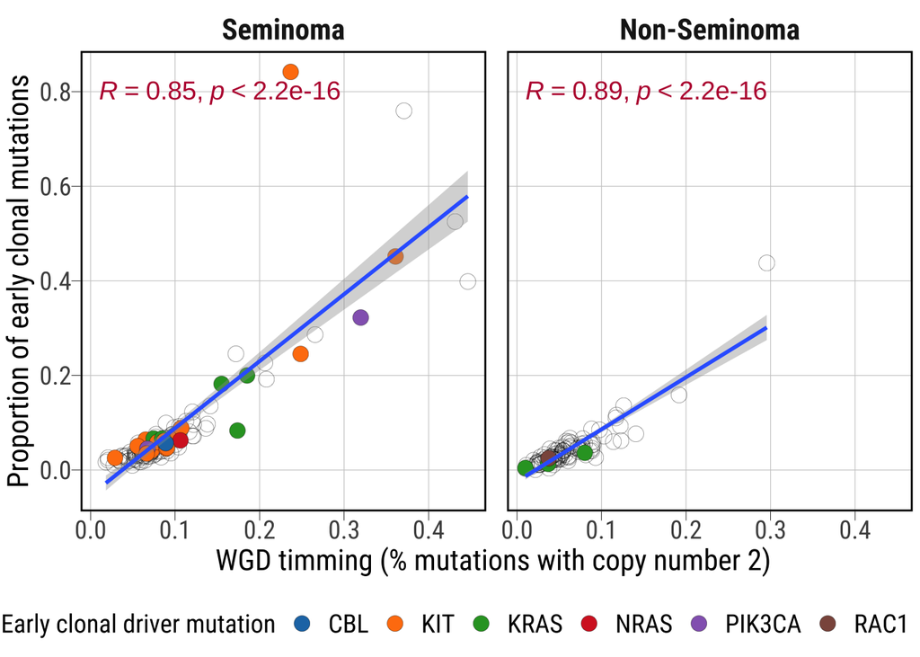

```r
pdata <- tdata %>%
  left_join(clsdata) %>%
  left_join(tmpdata %>% select(-Subtype)) %>%
  #left_join(tgct_maf %>% select(Tumor_Barcode,Hugo_Symbol) %>% unique() %>% filter(Hugo_Symbol %in% genelist)) %>%
  left_join(wgs_data %>% select(Tumor_Barcode, Subtype)) %>%
  arrange(!is.na(Hugo_Symbol)) %>%
  filter(WGD_Status == 'WGD', CLS == 'clonal [early]')


#ggrepel::geom_text_repel(aes(label=Hugo_Symbol))
pdata %>%
  ggplot(aes(Ratio, Freq)) +
  geom_point(aes(fill = Hugo_Symbol), pch = 21, size = 4, stroke = 0.1) +
  facet_wrap(~Subtype) +
  scale_fill_d3() +
  stat_smooth(method = "lm") +
  stat_cor(size = 5, col = ncicolpal[1], ) +
  #stat_regline_equation(label.y = c(60,64),label.x = c(4,4)) +
  scale_fill_d3() +
  #scale_color_manual(values = subtypecol) +
  scale_y_continuous(breaks = pretty_breaks(n = 5)) +
  scale_x_continuous(breaks = pretty_breaks(n = 5)) +
  #facet_wrap(~Subtype,scale='free')+
  labs(
    x = 'WGD timming (% mutations with copy number 2) ',
    y = 'Proportion of early clonal mutations',
    fill = 'Early clonal driver mutation'
  ) +
  theme_ipsum_rc(
    axis_text_size = 14,
    axis_title_just = 'm',
    axis_title_size = 16,
    grid = 'XY',
    ticks = T
  ) +
  panel_border(color = 'black') +
  theme(
    #axis.text.x = element_blank(),
    panel.spacing.x = unit(0.4, 'cm'),
    #axis.ticks.x = element_blank(),
    plot.margin = margin(4, 4, 4, 4),
    legend.position = 'bottom',
    legend.text = element_text(size = 14),
    legend.title = element_text(size = 14),
    strip.text.x = element_text(hjust = 0.5, face = 'bold', size = 16)
  ) +
  guides(fill = guide_legend(nrow = 1, byrow = TRUE))
```

## 8 Fig. 5f

Estimated cell divisions before WGD in seminomas versus non-seminomas, inferred from pre-WGD mutation burden. P-values from two-sided Wilcoxon rank-sum tests are shown above boxplots.

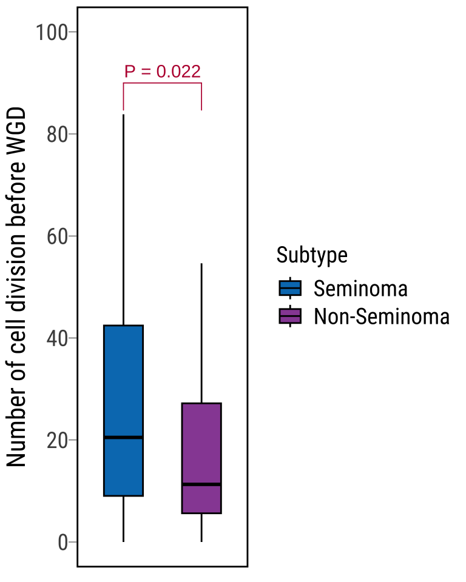

```r
load('../data/predup_with_divs.RData')
# box plot
my_comparisons <- list(c('Seminoma', 'Non-Seminoma'))

stat.test <- predup_with_divs %>%
  rstatix::wilcox_test(
    cell_divisions_mid ~ Subtype,
    comparisons = my_comparisons
  ) %>%
  rstatix::add_xy_position(x = "Subtype") %>%
  mutate(myformatted.p = paste0('P = ', round(p, 3))) %>%
  mutate(Subtype = NA, y.position = 90)

predup_with_divs %>%
  ggplot(aes(Subtype, cell_divisions_mid, fill = Subtype)) +
  geom_boxplot(width = 0.5, color = 'black', outlier.shape = NA) +
  #ggbeeswarm::geom_quasirandom(pch=21,size=2,width = 0.2,color="white",stroke=0.2,dodge.width=1)+
  #geom_hline(yintercept = 1,linetype=2,col=ncicolpal[2])+
  #geom_vline(xintercept = 1.5,col='#cccccc',size=0.2)+
  labs(x = NULL, y = 'Number of cell division before WGD') +
  scale_fill_manual(values = subtypecol, breaks = names(subtypecol)) +
  scale_y_continuous(breaks = pretty_breaks(n = 7),limits = c(0,100)) +
  theme_ipsum_rc(
    axis_text_size = 14,
    axis_title_just = 'm',
    axis_title_size = 16,
    grid = F,
    ticks = T
  ) +
  panel_border(color = 'black') +
  theme(
    axis.text.x = element_blank(),
    panel.spacing.x = unit(0.4, 'cm'),
    axis.ticks.x = element_blank(),
    plot.margin = margin(4, 4, 4, 4),
    legend.position = 'right',
    legend.text = element_text(size = 14),
    legend.title = element_text(size = 14),
    strip.text.x = element_text(hjust = 0.5, face = 'bold', size = 16)
  ) +
  scale_color_manual(values = c(ncicolpal[1], 'black')) +
  #guides(color='none')+
  stat_pvalue_manual(stat.test, label = "myformatted.p", color = ncicolpal[1])
```

## 9 Fig. 5g

Correlation between pre-WGD cell divisions and patient age at diagnosis in seminomas (left) and non-seminomas (right). Pearson R and P-value are shown above scatterplots. All boxplots display median, IQR, and whiskers extending to 1.5× IQR.

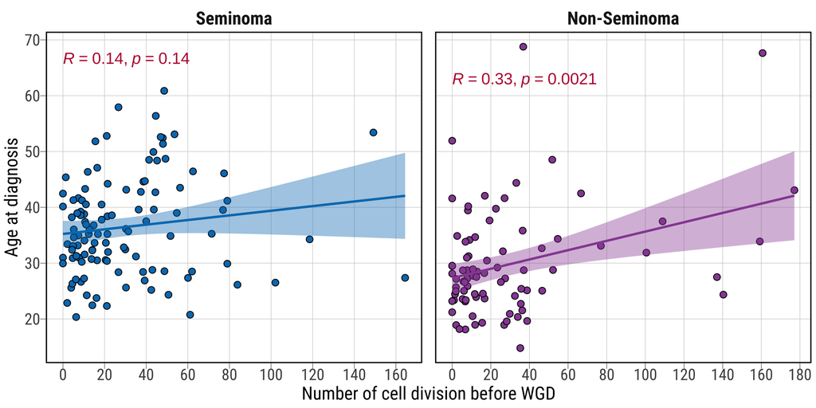

```r
predup_with_divs %>%
  ggplot(aes(cell_divisions_mid, age_at_diagnosis, , fill = Subtype)) +
  geom_point(pch = 21, size = 2.5) +
  stat_smooth(aes(fill = Subtype, color = Subtype), method = "lm") +
  stat_cor(size = 5, col = ncicolpal[1]) +
  #stat_regline_equation(label.y = c(60,64),label.x = c(4,4)) +
  scale_fill_manual(values = subtypecol) +
  scale_color_manual(values = subtypecol) +
  scale_y_continuous(breaks = pretty_breaks(n = 5)) +
  scale_x_continuous(breaks = pretty_breaks(n = 7)) +
  facet_wrap(~Subtype, scale = 'free_x') +
  labs(x = 'Number of cell division before WGD', y = 'Age at diagnosis') +
  theme_ipsum_rc(
    axis_text_size = 14,
    axis_title_just = 'm',
    axis_title_size = 16,
    grid = 'XY',
    ticks = T
  ) +
  panel_border(color = 'black') +
  theme(
    #axis.text.x = element_blank(),
    panel.spacing.x = unit(0.4, 'cm'),
    #axis.ticks.x = element_blank(),
    plot.margin = margin(4, 4, 4, 4),
    legend.position = 'bottom',
    legend.text = element_text(size = 14),
    legend.title = element_text(size = 14),
    strip.text.x = element_text(hjust = 0.5, face = 'bold', size = 16)
  ) +
  guides(fill = 'none', col = 'none')
```